# PSYC 532: Final Analysis

Ryan Wong

November 29, 2015

## Load Packages

Prepare RStudio environment for all tasks

```r
# Load the necessary packages.
base::require(base)
base::require(knitr)
base::require(markdown)
base::require(testit)
base::require(plyr)
base::require(dplyr)
base::require(reshape2)
base::require(stringr)
base::require(stats)
base::require(ggplot2)
base::require(extrafont)
base::require(gamair)
base::require(lme4)
base::require(nlme)
base::require(leaps)
```

```r
# load themes used to style graphs
source("./scripts/graphs/graph_themes.R")
```

## Load Data

Link to the data source

```r
pathDir <- getwd()
myExtract <- file.path(pathDir,"data/derived/hrs/hrs_analysis")
pathSourceData <- paste0(myExtract,".csv")
SourceData <- read.csv(pathSourceData,header=TRUE, skip=0,sep=",")
hrs_analysis <- SourceData
```

## Start Analysis

For this analysis, I will use linear mixed effects modeling to explore the data.

I plot each individual’s BMI and age as I expect there to be significant individual difference in the changes of BMI over time.

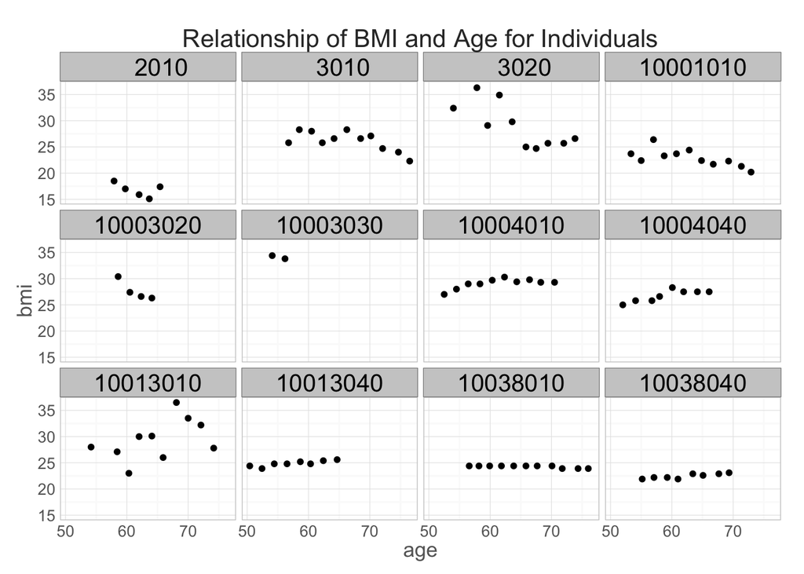

```r
p <- ggplot(hrs_analysis)
p <- p + geom_point(aes
                    (x=age,y=bmi
                    ))
p <- p + labs(title="Relationship of BMI and Age for Individuals")
p <- p + theme1
p <- p + facet_wrap(~id)
p
```

A cursory examination indicates that there is a great deal of variation between people.

## Modeling

##### Fixed Effect Only Model (M00)

We begin by modeling a fixed-effect only model. Note that for this model and all subsequent models, indicators of model fit are calculated for later use (AIC, BIC, and deviance).

```r
m00 <- lm(bmi~age, data=hrs_analysis)
AIC00 <- AIC(m00)
BIC00 <- BIC(m00)
dev00 <- deviance(m00)
(m00_sum <- summary(m00))
```

```
Call:
lm(formula = bmi ~ age, data = hrs_analysis)

Residuals:
     Min       1Q   Median       3Q      Max
-10.7376  -2.2624  -0.4601   2.1331  10.9032

Coefficients:
            Estimate Std. Error t value Pr(>|t|)
(Intercept) 29.30791    4.09613   7.155 1.66e-10 ***
age         -0.05451    0.06493  -0.840    0.403
---
Signif. codes:  0 '***' 0.001 '**' 0.01 '*' 0.05 '.' 0.1 ' ' 1

Residual standard error: 3.974 on 96 degrees of freedom
Multiple R-squared:  0.007288,  Adjusted R-squared:  -0.003053
F-statistic: 0.7048 on 1 and 96 DF,  p-value: 0.4033
```

##### Model 0 (Empty)

```r
# empty model. Only intercept is modeled as random
m0 <- lme4::lmer(formula = bmi ~ 1 + (1|id), data=hrs_analysis)
AIC0 <- AIC(m0)
BIC0 <- BIC(m0)
dev0 <- deviance(m0)
(m0_sum <- summary(m0))
```

```
Linear mixed model fit by REML ['lmerMod']
Formula: bmi ~ 1 + (1 | id)
   Data: hrs_analysis

REML criterion at convergence: 466.9

Scaled residuals:
    Min      1Q  Median      3Q     Max
-2.9187 -0.4277  0.0429  0.3339  3.3914

Random effects:
 Groups   Name        Variance Std.Dev.
 id       (Intercept) 17.449   4.177
 Residual              4.707   2.169
Number of obs: 98, groups:  id, 12

Fixed effects:
            Estimate Std. Error t value
(Intercept)   26.073      1.231   21.18
```

##### Model 1

Next, age is modeled as a fixed-effect.

```r
# age is modeled as fixed
m1 <- lme4::lmer(formula = bmi ~ 1 + age + (1|id), data=hrs_analysis)
AIC1 <- AIC(m1)
BIC1 <- BIC(m1)
dev1 <- deviance(m1)
(m1_sum <- summary(m1))
```

```
Linear mixed model fit by REML ['lmerMod']
Formula: bmi ~ 1 + age + (1 | id)
   Data: hrs_analysis

REML criterion at convergence: 468.9

Scaled residuals:
    Min      1Q  Median      3Q     Max
-3.0773 -0.4892 -0.0166  0.3741  3.4279

Random effects:
 Groups   Name        Variance Std.Dev.
 id       (Intercept) 17.087   4.134
 Residual              4.631   2.152
Number of obs: 98, groups:  id, 12

Fixed effects:
            Estimate Std. Error t value
(Intercept) 30.05795    2.73757  10.980
age         -0.06428    0.03954  -1.626

Correlation of Fixed Effects:
    (Intr)
age -0.896
```

##### Model 2

Next, we input the intercept and slope of age as random-effects (estimated for each person)

```r
# intercept and slope of ages is random (estimated for each person)
m2 <- lme4::lmer(formula = bmi ~ 1 + age + (1 + age |id), data=hrs_analysis)
AIC2 <- AIC(m2)
BIC2 <- BIC(m2)
dev2 <- deviance(m2)
(m2_sum <- summary(m2))
```

```
Linear mixed model fit by REML ['lmerMod']
Formula: bmi ~ 1 + age + (1 + age | id)
   Data: hrs_analysis

REML criterion at convergence: 448.2

Scaled residuals:
    Min      1Q  Median      3Q     Max
-3.0291 -0.3540 -0.0243  0.2527  3.6683

Random effects:
 Groups   Name        Variance  Std.Dev. Corr
 id       (Intercept) 230.84389 15.1935
          age           0.05208  0.2282  -0.96
 Residual               3.04144  1.7440
Number of obs: 98, groups:  id, 12

Fixed effects:
            Estimate Std. Error t value
(Intercept) 30.33400    5.14482   5.896
age         -0.06775    0.07940  -0.853

Correlation of Fixed Effects:
    (Intr)
age -0.972
```

##### Model 3

Next, we add in arthritis as a fixed-effect that predicts the random intercept.

```r
# random intercept and slope + use arthritis to predict random intercept
m3 <- lme4::lmer(formula = bmi ~ 1 + age + arthr + (1 + age |id), data=hrs_analysis)
AIC3 <- AIC(m3)
BIC3 <- BIC(m3)
dev3 <- deviance(m3)
(m3_sum <- summary(m3))
```

```
Linear mixed model fit by REML ['lmerMod']
Formula: bmi ~ 1 + age + arthr + (1 + age | id)
   Data: hrs_analysis

REML criterion at convergence: 446.8

Scaled residuals:
    Min      1Q  Median      3Q     Max
-3.0134 -0.3602 -0.0205  0.2513  3.6467

Random effects:
 Groups   Name        Variance  Std.Dev. Corr
 id       (Intercept) 228.42274 15.1137
          age           0.05226  0.2286  -0.96
 Residual               3.07554  1.7537
Number of obs: 98, groups:  id, 12

Fixed effects:
            Estimate Std. Error t value
(Intercept) 30.42838    5.16467   5.892
age         -0.06988    0.08071  -0.866
arthr        0.12822    0.78409   0.164

Correlation of Fixed Effects:
      (Intr) age
age   -0.971
arthr  0.107 -0.160
```

##### Model 4

Finally, we add arthritis as a predictor of both the intercept and the slope at the second level.

```r
# enter arthritis as predictor on second level for both intercept and slope
m4 <- lme4::lmer(formula = bmi ~ 1 + age + arthr + age:arthr + (1 + age |id), data=hrs_analysis)
AIC4 <- AIC(m4)
BIC4 <- BIC(m4)
dev4 <- deviance(m4)
(m4_sum <- summary(m4))
```

```
Linear mixed model fit by REML ['lmerMod']
Formula: bmi ~ 1 + age + arthr + age:arthr + (1 + age | id)
   Data: hrs_analysis

REML criterion at convergence: 446.7

Scaled residuals:
    Min      1Q  Median      3Q     Max
-3.0054 -0.3553 -0.0017  0.2486  3.6181

Random effects:
 Groups   Name        Variance  Std.Dev. Corr
 id       (Intercept) 168.46097 12.9793
          age           0.04095  0.2024  -0.95
 Residual               3.09681  1.7598
Number of obs: 98, groups:  id, 12

Fixed effects:
             Estimate Std. Error t value
(Intercept) 26.062554   5.325290   4.894
age          0.004197   0.086665   0.048
arthr       13.464780   8.423885   1.598
age:arthr   -0.221025   0.140035  -1.578

Correlation of Fixed Effects:
          (Intr) age    arthr
age       -0.973
arthr     -0.487  0.505
age:arthr  0.498 -0.521 -0.996
```

## Graphing Models

We add each model as a new variable into the dataset. We then melt the data into a long form.

```r
hrs_analysis$m0 <- predict(m0)
hrs_analysis$m1 <- predict(m1)
hrs_analysis$m2 <- predict(m2)
hrs_analysis$m3 <- predict(m3)
hrs_analysis$m4 <- predict(m4)

head(hrs_analysis)
```

```
    id wave      age sex  bmi arthr       m0       m1       m2       m3       m4
1 2010    1 57.91667   2 18.5     0 17.25563 17.50499 17.44533 17.43876 17.62638
2 2010    2 59.75000   2 17.0     0 17.25563 17.38715 17.28769 17.24838 17.55286
3 2010    3 62.00000   2 15.9     1 17.25563 17.24252 17.09422 17.14295 17.22385
4 2010    4 63.66667   2 15.1     1 17.25563 17.13539 16.95091 16.96988 16.78864
5 2010    5 65.41666   2 17.4     1 17.25563 17.02290 16.80043 16.78815 16.33168
6 3010    1 56.75000   1 25.8     0 26.13484 26.74794 27.86136 27.85929 27.70931
```

```r
dsPred <- tidyr::gather(hrs_analysis, "model", "predicted_bmi", 7:11)
head(dsPred)
```

```
    id wave      age sex  bmi arthr model predicted_bmi
1 2010    1 57.91667   2 18.5     0    m0      17.25563
2 2010    2 59.75000   2 17.0     0    m0      17.25563
3 2010    3 62.00000   2 15.9     1    m0      17.25563
4 2010    4 63.66667   2 15.1     1    m0      17.25563
5 2010    5 65.41666   2 17.4     1    m0      17.25563
6 3010    1 56.75000   1 25.8     0    m0      26.13484
```

Finally we graph all the models onto the data to see how well they fit. We see that there are 3 models that fit the data quite well: Models 2, 3, and 4. Due to graph size constraints, we are unable to ascertain just by looking which model is the best fit. Thus we must calculate the model that best fits the data.

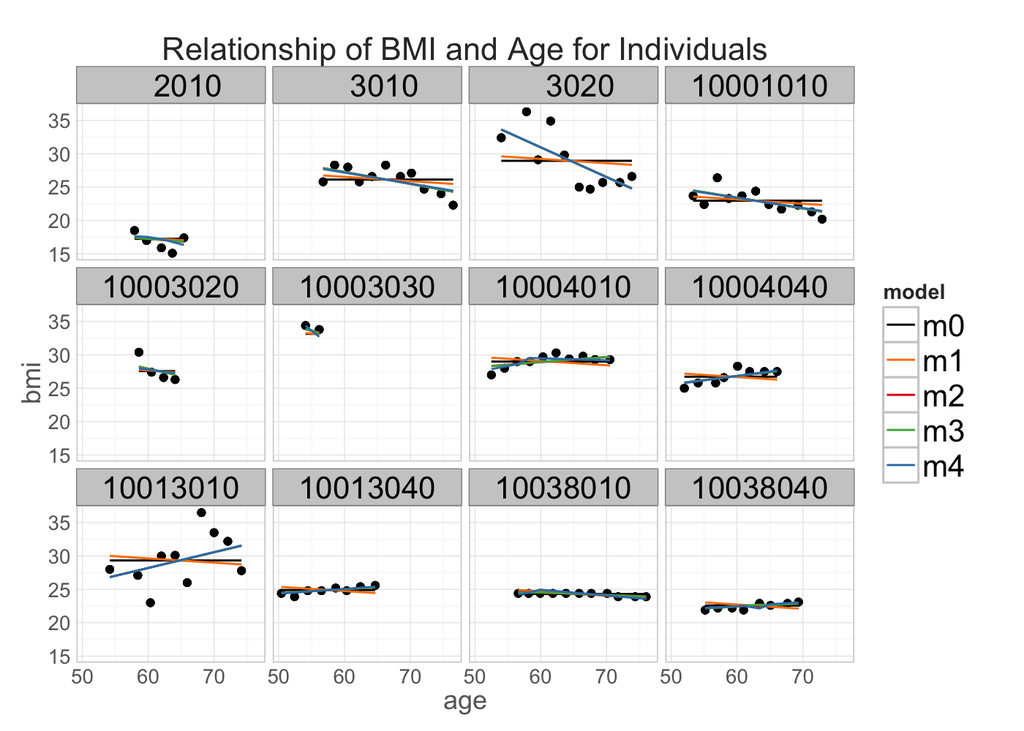

```r
pg <- ggplot2::ggplot(dsPred, aes(x=age, y=bmi)) +
  geom_point() +
  geom_line(aes(y=predicted_bmi, group=model, color=model))+
  facet_wrap(~id)+
  scale_color_manual(values=c("m0"="black", "m1"="#ff7f00", "m2"="#e41a1c", "m3"="#4daf4a",
                              "m4"="#377eb8"))+
  theme1
pg <- pg + labs(title="Relationship of BMI and Age for Individuals")
pg
```

## Checking the Model Fits

We first combine the AIC, BIC, and deviance values for each model into 3 variables. We set these new variables into a new dataset. We use Model as the indicator for grouping.

```r
AIC <- c(AIC00, AIC0, AIC1, AIC2, AIC3, AIC4)
BIC <- c(BIC00, BIC0, BIC1, BIC2, BIC3, BIC4)
Devall <- c(dev00, dev0, dev1, dev2, dev3, dev4)
```

Note that for the indices of fit, the lower the number, the better the fit. There is a small caveat when looking at deviance. Deviance will always go down when you add more variables into the model. This is a statistical artifact and does not always tell use the most efficient use of predictors that we might fit in a model.

Now we can see which model fits the data the best: Model 2

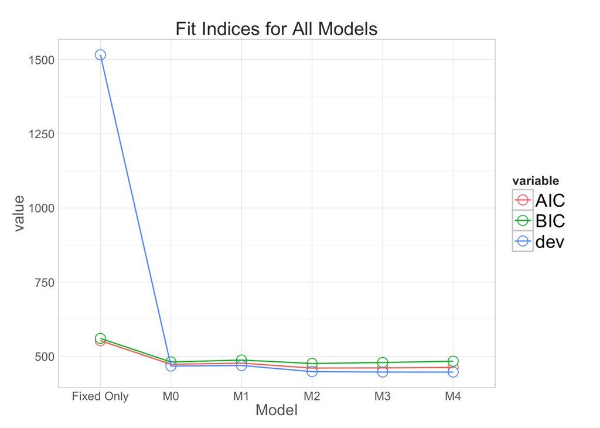

```r
d <- data.frame(Model=0:5, AIC=0:5, BIC=0:5, dev=0:5)
d$AIC <- AIC
d$BIC <- BIC
d$dev <- Devall
d$Model <- factor(d$Model)
d$Model <- as.character(d$Model)
d$Model[d$Model == "0"] <- "Fixed Only"
d$Model[d$Model == "1"] <- "M0"
d$Model[d$Model == "2"] <- "M1"
d$Model[d$Model == "3"] <- "M2"
d$Model[d$Model == "4"] <- "M3"
d$Model[d$Model == "5"] <- "M4"
d <- melt(d, Model="Model", AIC="AIC", BIC="BIC", dev="dev")


f <- ggplot2::ggplot(d, aes(x=Model, y=value,
                            group = variable, colour = variable)) +
  geom_point(size=4, shape=21, fill="white") +
  geom_line(aes(y=value, group=variable, color=variable))+
  theme1
f <- f + labs(title="Fit Indices for All Models")
f
```

Therefore, when predicting BMI in this group, using a model that contains a fixed-effect of age, random-effects of individual age slopes/intercepts, and a random intercept is the best option.